# Grupo 4: Percepción de inseguridad en Lima Metropolitana

# Análisis de la percepción de inseguridad en Lima Metropolitana

## Victimización por robo de vehículo

### En el caso del robo de vehículo, existe una clara diferencia entre Lima Moderna y el resto de sectores de Lima Metropolitana. En Lima Moderna cerca del 30% de encuestados manifestaron que sí sienten que pueden ser víctimas del robo de su vehículo, mientras que en otros sectores limeños, esta sensación no pasa del 15% de encuestados.

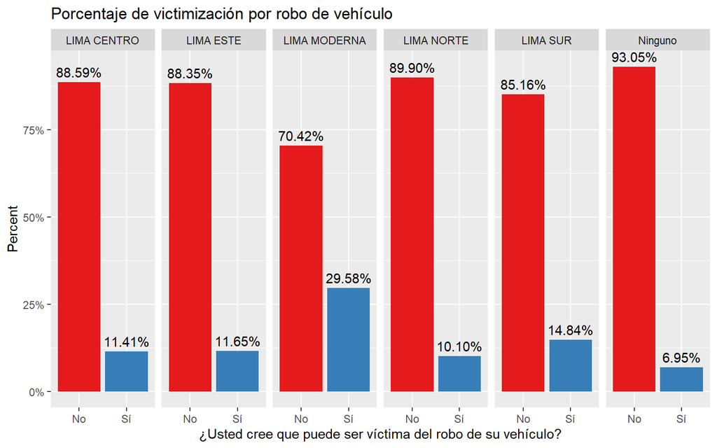

```r
lima |>
  filter(!is.na(Robo_vehiculo)) |>
  ggplot(mapping = aes(x= Robo_vehiculo,  group=Zona)) +
  geom_bar(aes(y = ..prop.., fill = factor(..x..)), stat="count") +
  geom_text(aes( label = scales::percent(..prop..),
                   y= ..prop.. ), stat= "count", vjust = -.5) + labs(y = "Percent", fill="¿Usted cree que puede ser víctima del robo de su vehículo?") + facet_grid(~Zona) + scale_y_continuous(labels=percent)+labs(title="Porcentaje de victimización por robo de vehículo", x="¿Usted cree que puede ser víctima del robo de su vehículo?")+ scale_fill_brewer(palette = "Set1")+theme(legend.position = "bottom")+theme(legend.position = "none")
```

### Además alanalizar la victimización por robo de vehículo, por sexo, se encontró que existe una mayor percepción de inseguridad por parte de las hombres, principalmente en las zonas de Lima este, donde el 60.54% de hombres señala sentirse más propensos a ser sufrir el robo de sus vehículos, mientras que el porcentaje de mujeres es de 39.46%. Este porecentaje, para los hombres, es mayor en Lima norte (61.68%), mientras que para las mujeres es menor (38.32%).

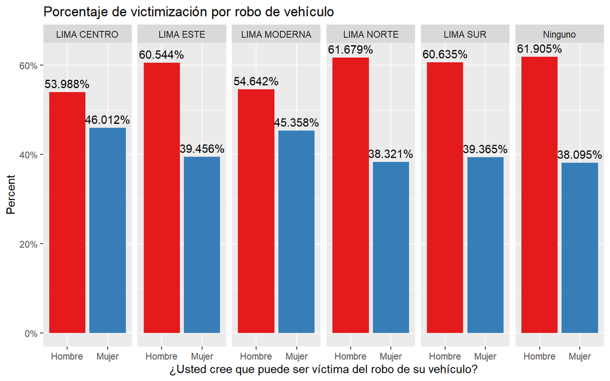

```r
vehi_sexo <- lima[lima$Robo_vehiculo %in% c("Sí"),]
vehi_sexo |>
  filter(!is.na(Robo_vehiculo)) |>
  ggplot(mapping = aes(x=Sexo ,  group=Robo_vehiculo)) +
  geom_bar(aes(y = ..prop.., fill = factor(..x..)), stat="count") +
  geom_text(aes( label = scales::percent(..prop..),
                   y= ..prop.. ), stat= "count", vjust = -.5) + labs(y = "Percent", fill="¿Usted cree que puede ser víctima del robo de su vehículo?") + facet_grid(~Zona) + scale_y_continuous(labels=percent)+labs(title="Porcentaje de victimización por robo de vehículo", x="¿Usted cree que puede ser víctima del robo de su vehículo?")+ scale_fill_brewer(palette = "Set1")+theme(legend.position = "bottom")+theme(legend.position = "none")
```

## Victimización por robo de vivienda

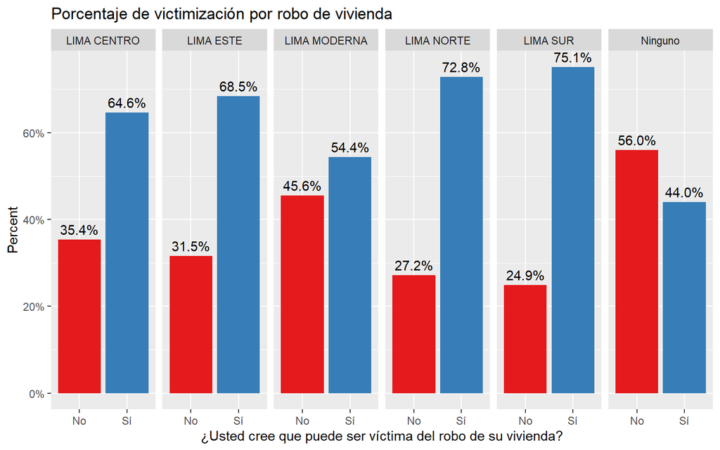

```r
lima |>
  filter(!is.na(Robo_vivienda)) |>
  ggplot(lima, mapping = aes(x= Robo_vivienda,  group=Zona)) +
  geom_bar(aes(y = ..prop.., fill = factor(..x..)), stat="count") +
  geom_text(aes( label = scales::percent(..prop..),
                   y= ..prop.. ), stat= "count", vjust = -.5) + labs(y = "Percent", fill="¿Usted cree que puede ser víctima del robo de su vehículo?") + facet_grid(~Zona) + scale_y_continuous(labels=percent)+labs(title="Porcentaje de victimización por robo de vivienda", x="¿Usted cree que puede ser víctima del robo de su vivienda?")+ scale_fill_brewer(palette = "Set1")+theme(legend.position = "bottom")+theme(legend.position = "none")
```

### Además, al realizar el análisis por sexo, se identifica una mayor percepción de victimización por robo de vivienda por parte de las mujeres en todas las zonas, principalmente en Lima moderna, donde la diferencia entre hombres (44.25%) y mujeres (55.75%) es de 11.5%. Mientras que la zona que muestra una menor diferencia es Lima sur, con 1.94%. Las demás zonas muestran en promedio una diferencia del 5.06%.

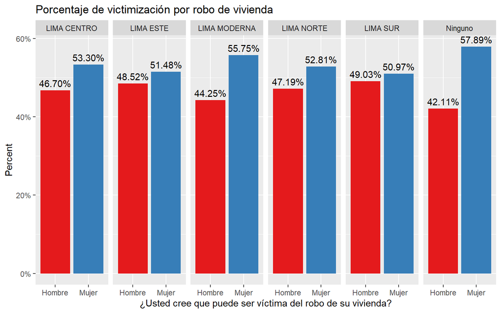

```r
vivi_sexo <- lima[lima$Robo_vivienda %in% c("Sí"),]

vivi_sexo |>
  filter(!is.na(Robo_vivienda)) |>
  ggplot(lima, mapping = aes(x= Sexo,  group=Robo_vivienda)) +
  geom_bar(aes(y = ..prop.., fill = factor(..x..)), stat="count") +
  geom_text(aes( label = scales::percent(..prop..),
                   y= ..prop.. ), stat= "count", vjust = -.5) + labs(y = "Percent", fill="¿Usted cree que puede ser víctima del robo de su vehículo?") + facet_grid(~Zona) + scale_y_continuous(labels=percent)+labs(title="Porcentaje de victimización por robo de vivienda", x="¿Usted cree que puede ser víctima del robo de su vivienda?")+ scale_fill_brewer(palette = "Set1")+theme(legend.position = "bottom")+theme(legend.position = "none")
```

## Confianza en la PNP en Lima Metropolitana

### De acuerdo al Gráfico de Barras, en los 5 sectores geográficos de Lima Metropolitana, más del 50% de los y las encuestadas tiene nada o poca confianza en la Policia Nacional del Perú. De todos los sectores, Lima moderna es que el manifiesta mayor confianza en la PNP (alrededor de 40% de los encuestados), mientras que Lima Sur, Lima Este y Lima Norte son los sectores con mayores niveles de desconfianza en la PNP (en los tres sectores, alrededor del 75% de la población señala su nula o poca confianza a esta institución). Como se vio anterioremente, estos tres sectores son los que presentan mayores niveles de victimización en Lima Metropolitana. Una de las razones podría ser, precisamente, su bajo nivel de confianza en las fuerzas del orden.

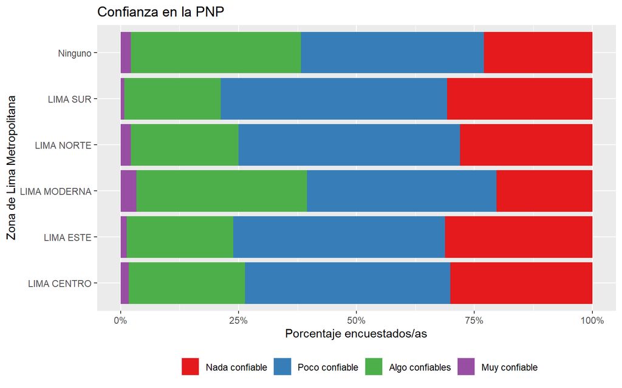

```r
lima |>
  filter(!is.na(Confianza_PNP)) %>%
  ggplot(lima, mapping = aes(x=Zona,fill=Confianza_PNP))+geom_bar(position="fill")+labs(y="Porcentaje encuestados/as",x="Grupos de edad")+coord_flip()+ scale_y_continuous(labels=percent)+labs(title="Confianza en la PNP", x="Zona de Lima Metropolitana")+ scale_fill_brewer(palette = "Set1")+theme(legend.position = "bottom")+ theme(legend.title = element_blank())
```

## Siente inseguridad en la calle

```r
Z_calle = calle |>
    filter(Robo_calle == "Sí") |>
    group_by(Zona) |>
    summarise(Robo_calle = n())
Z_calle
```

```
## # A tibble: 6 x 2
##   Zona         Robo_calle
##   <chr>             <int>
## 1 LIMA CENTRO        1429
## 2 LIMA ESTE          2523
## 3 LIMA MODERNA       3496
## 4 LIMA NORTE         2713
## 5 LIMA SUR           2123
## 6 Ninguno             302
```

```r
D_calle = calle |>
    filter(Robo_calle == "Sí") |>
    group_by(NOMBREDI) |>
    summarise(Robo_calle = n())
D_calle
```

```
## # A tibble: 39 x 2
##    NOMBREDI      Robo_calle
##    <chr>              <int>
##  1 ANCON                300
##  2 ATE                  452
##  3 BARRANCO             246
##  4 BREÑA                302
##  5 CARABAYLLO           384
##  6 CHACLACAYO           267
##  7 CHORRILLOS           314
##  8 COMAS                463
##  9 EL AGUSTINO          362
## 10 INDEPENDENCIA        344
## # ... with 29 more rows
```

## Siente que puede ser víctima de robo de su vehículo

```r
Z_vehiculo = vehiculo |>
    filter(Robo_vehiculo == "Sí") |>
    group_by(Zona) |>
    summarise(Robo_vehiculo = n())
Z_vehiculo
```

```
## # A tibble: 6 x 2
##   Zona         Robo_vehiculo
##   <chr>                <int>
## 1 LIMA CENTRO            163
## 2 LIMA ESTE              294
## 3 LIMA MODERNA          1034
## 4 LIMA NORTE             274
## 5 LIMA SUR               315
## 6 Ninguno                 21
```

```r
D_vehiculo = vehiculo |>
    filter(Robo_vehiculo == "Sí") |>
    group_by(NOMBREDI) |>
    summarise(Robo_vehiculo = n())
D_vehiculo
```

```
## # A tibble: 37 x 2
##    NOMBREDI      Robo_vehiculo
##    <chr>                 <int>
##  1 ANCON                    20
##  2 ATE                      44
##  3 BARRANCO                 57
##  4 BREÑA                    21
##  5 CARABAYLLO               34
##  6 CHACLACAYO               40
##  7 CHORRILLOS               61
##  8 COMAS                    45
##  9 EL AGUSTINO              46
## 10 INDEPENDENCIA            28
## # ... with 27 more rows
```

## Siente que puede ser víctima de robo de vivienda

```r
Z_vivienda = vivienda |>
    filter(Robo_vivienda == "Sí") |>
    group_by(Zona) |>
    summarise(Robo_vivienda = n())
Z_vivienda
```

```
## # A tibble: 6 x 2
##   Zona         Robo_vivienda
##   <chr>                <int>
## 1 LIMA CENTRO            923
## 2 LIMA ESTE             1727
## 3 LIMA MODERNA          1903
## 4 LIMA NORTE            1975
## 5 LIMA SUR              1595
## 6 Ninguno                133
```

```r
D_vivienda = vivienda |>
    filter(Robo_vivienda == "Sí") |>
    group_by(NOMBREDI) |>
    summarise(Robo_vivienda = n())
D_vivienda
```

```
## # A tibble: 39 x 2
##    NOMBREDI      Robo_vivienda
##    <chr>                 <int>
##  1 ANCON                   250
##  2 ATE                     307
##  3 BARRANCO                146
##  4 BREÑA                   133
##  5 CARABAYLLO              287
##  6 CHACLACAYO              173
##  7 CHORRILLOS              221
##  8 COMAS                   336
##  9 EL AGUSTINO             249
## 10 INDEPENDENCIA           210
## # ... with 29 more rows
```

```r
Victimizacion_lima <- merge(Ca_Vi, D_vehiculo, by.x = "NOMBREDI",
             by.y = "NOMBREDI", all.x = TRUE, all.y = FALSE)
```

## Bibliografía

### COSTA, Gino y CARLOS Romero. 2011. Inseguridad en el Perú:¿ qué hacer?. Lima: Ciudad Nuestra.

### LOPEZ, Noam. 2014. Inseguridad y percepción de inseguridad en Lima, Perú. Lima: Instituto de Opinión Pública de la Pontificia Universidad Católica del Perú.